# Um curso introdutório do pacote ggplot2 disponível no R

Para escolhermos a cor da forma geométrica dos gráficos gerados pelo `ggplot2`, temos três comandos: `color`, `colour` e `fill`. O comando `color` é utilzado nos gráficos de dispersão (pontos) pois, por definição, pontos não possuem área. O comando `colour` é utilizado quando desejamos colorir a borda de um ente geométrico que represente uma `área`: caixas, barras, etc. O comando `fill` é utilizado para colorir o interior desses entes geométricos (preenchimento). Além disso, esses comandos podem ser utilizados dentro do comando aes ou fora dele, diferenciando apenas no argumento a ser utilizado. Os exemplos a seguir ilustram bem sua utilização.

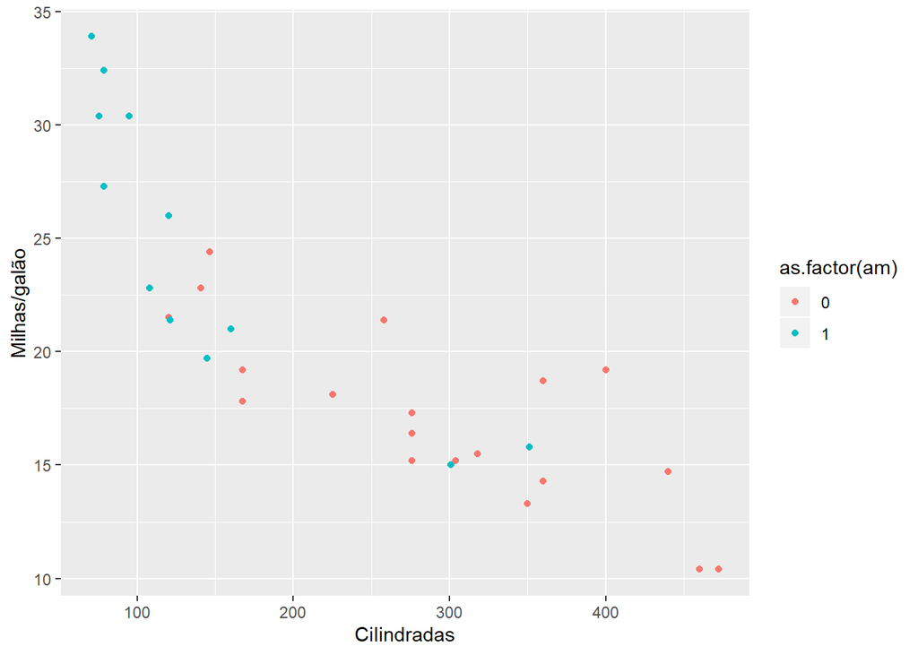

```r
 ggplot(mtcars) +
  geom_point(mapping = aes(x= disp, y=mpg, color=as.factor(am))) +
  labs(x="Cilindradas", y="Milhas/galão")
```

Note que utilzamos o comando `color` pois trata-se de um gráfico de dispersão. Além disso, a variável `am`, que significa tipo de tranmissão e é rotulada como: `0` representando transmissão automática e `1` representando transmissão manual, foi escolhida para ser utilizada no comando `color`. Então, os pontos do nosso gráfico foram coloridos de acordo com `os níveis` dessa terceira variável. Além disso, foi criado uma legenda automática.

No próximo exemplo, construímos o mesmo gráfico, porém agora com o comando `color` fora do comando `aes`. Note que agora temos a liberdade de escolha da cor que quisermos para os pontos do gráfico. Porém, uma legenda automática não é criada. Mais adiante veremos como construir uma legenda.

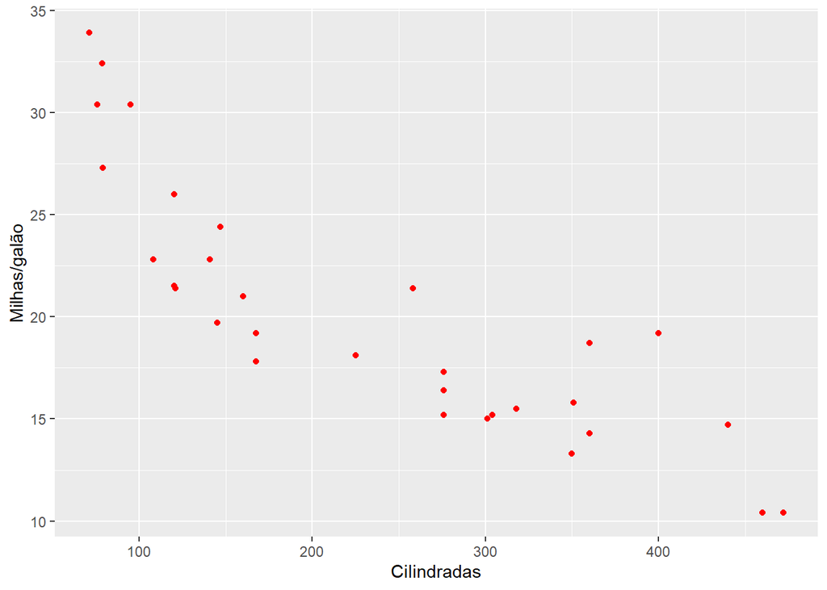

```r
 ggplot(mtcars) +
  geom_point(mapping = aes(x= disp, y=mpg), color=c("red"))+
  labs(x="Cilindradas", y="Milhas/galão")
```

Então podemos concluir que todos os comandos que estão dentro da função `aes` são relacionados a `variáveis`. Vamos agora apresentar um exemplo da construção de um `boxplot`, onde vamos utilizar os comandos `colour` e `fill`. A variável utilizada será a `mpg`, que é contínua.

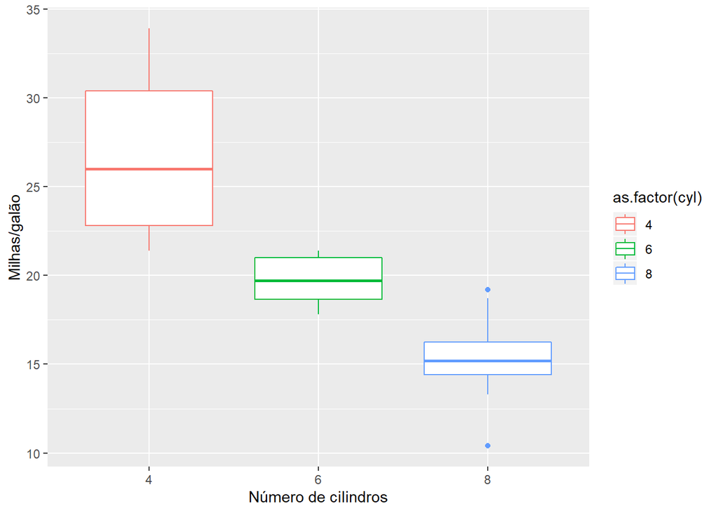

```r
 ggplot(mtcars) +
  geom_boxplot(aes(x = as.factor(cyl), y = mpg, colour=as.factor(cyl))) +
  labs(x = "Número de cilindros", y = "Milhas/galão")
```

Note que agora utilizamos o comando `colour` com a variável `cyl`. Como dissemos anteriormente, apenas a borda das caixas do boxplot foi colorida. A mesma foi colorida de acordo com os níveis da variável `cyl`.

No próximo passo vamos utilizar o comando `fill`. Vejamos a diferença.

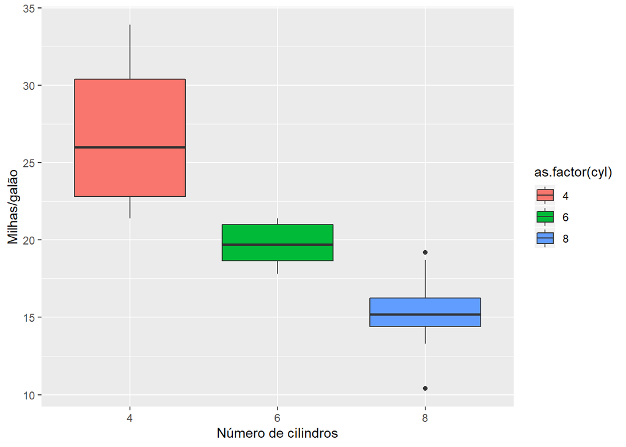

```r
 ggplot(mtcars) +
  geom_boxplot(aes(x = as.factor(cyl), y = mpg, fill=as.factor(cyl))) +
  labs(x = "Número de cilindros", y = "Milhas/galão")
```

Os comandos `colour` e `fill` podem ser utilizados conjuntamente. Vejamos.

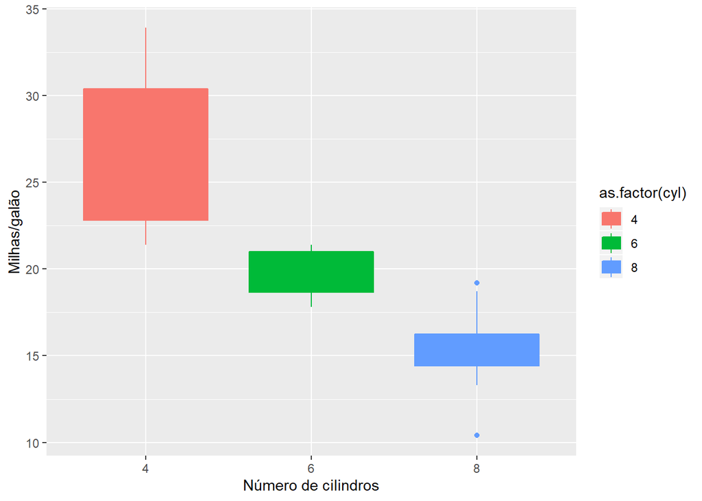

```r
 ggplot(mtcars) +
  geom_boxplot(aes(x = as.factor(cyl), y = mpg, fill=as.factor(cyl),
                   colour=as.factor(cyl))) +
  labs(x = "Número de cilindros", y = "Milhas/galão")
```

Note que, neste último caso, o `boxplot` está fora dos padrões. Não conseguimos identificar quem é a `mediana`, nem os `quartis`. Isso ocorre que por não temos a liberdade de escolha de cores quando os comandos `color`, `colour` e `fill` são utilizados dentro da função `aes`.

Neste momento, vamos utilizar estes comando fora da função `aes`. Vejamos a diferença

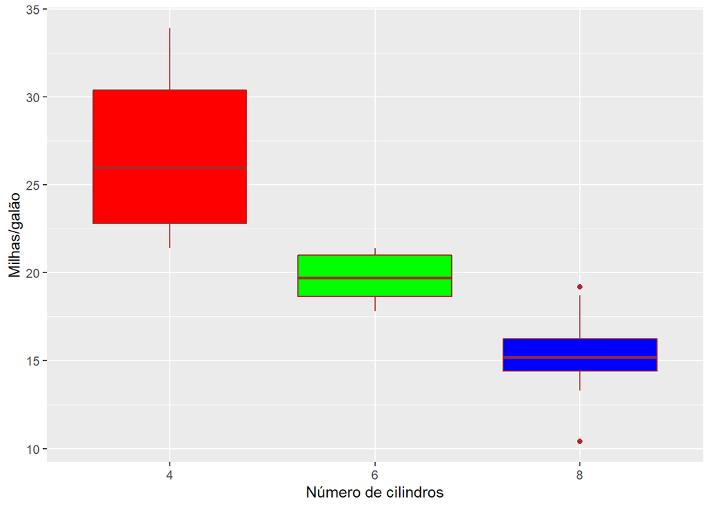

```r
 ggplot(mtcars) +
  geom_boxplot(aes(x = as.factor(cyl), y = mpg), fill=c("red", "green", "blue"),
               colour="brown") +
  labs(x = "Número de cilindros", y = "Milhas/galão")
```

Podemos ainda escolher a tonalidade das cores que escolhemos. Para tal, basta darmos o comando `alpha`. Os valores de alpha estão entre `0` e `1`. Valores mais próximos de `0` indicam tonalidade mais `fraca`. Vejamos.

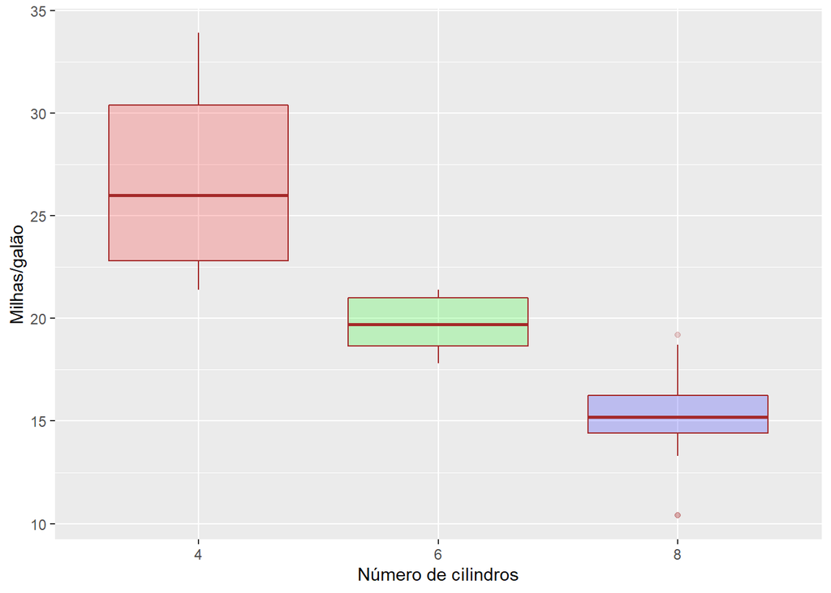

```r
 ggplot(mtcars) +
  geom_boxplot(aes(x = as.factor(cyl), y = mpg), fill=c("red", "green", "blue"),
               colour="brown", alpha=0.2) +
  labs(x = "Número de cilindros", y = "Milhas/galão")
```

Como dissemos anteriormente, o `ggplot2` permite ao usuário a liberdade de escolha para formatar seus gráficos e deixá-los apresentáveis. Observe que estes gráficos ainda não apresentam uma boa qualidade. Caso desejarmos retirar as `linhas de grade` que estão no plano de fundo da área do gráfico, acrescentarmos `legenda` manualmente, escolhermos a `fonte`, o `tamanho` de letra dos rótulos, destacarmos os `eixos`, entre outras coisas, é possível com o `ggplot2`. Os comandos a seguir fazem este trabalho. Construímos o mesmo gráfico um grande número de vezes, cada um com sua particularidade.

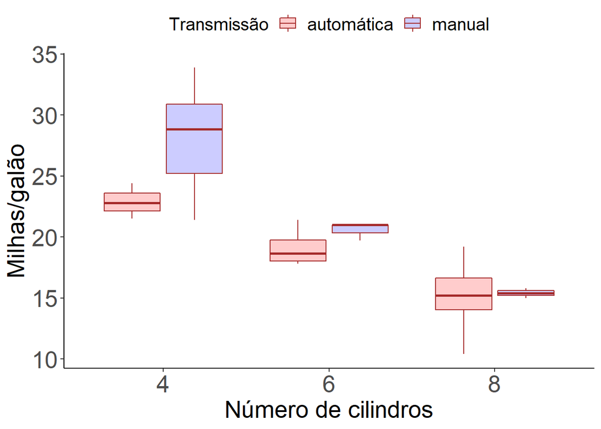

```r
 ggplot(mtcars) +
  geom_boxplot(aes(x = as.factor(cyl), y = mpg, fill=as.factor(am)), colour="brown",
               alpha=0.2) +
  labs(x = "Número de cilindros", y = "Milhas/galão") +
  theme_bw() +
  theme(legend.position="top",
        legend.box = "horizontal",legend.title=element_text(size=15),
        legend.text=element_text(size=15), axis.text=element_text(size=20),
        axis.title=element_text(size=20), axis.line = element_line(colour = "black"),
        panel.grid.major = element_blank(),
        panel.grid.minor = element_blank(),
        panel.border = element_blank(),
        panel.background = element_blank()) +
  scale_fill_manual(values=c("red", "blue"),
                       name="Transmissão",
                       breaks=c("0", "1"),
                       labels=c("automática", "manual"))
```

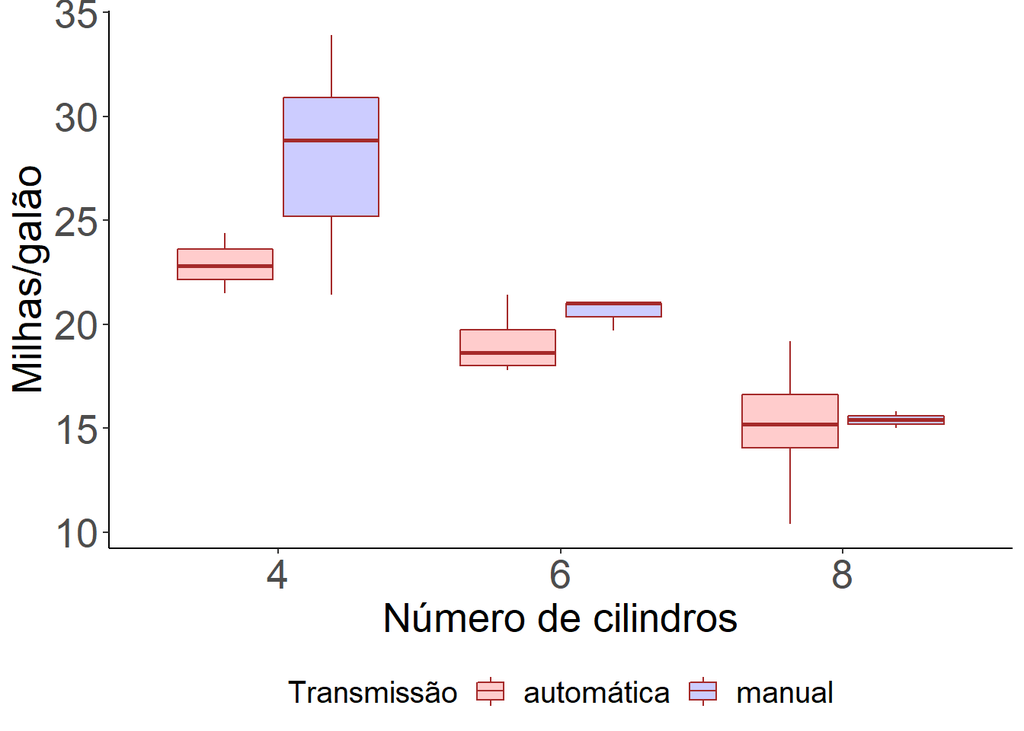

```r
 ggplot(mtcars) +
  geom_boxplot(aes(x = as.factor(cyl), y = mpg, fill=as.factor(am)), colour="brown",
               alpha=0.2) +
  labs(x = "Número de cilindros", y = "Milhas/galão") +
  theme_bw() +
  theme(legend.position="bottom",
        legend.box = "horizontal",legend.title=element_text(size=15),
        legend.text=element_text(size=15), axis.text=element_text(size=20),
        axis.title=element_text(size=20), axis.line = element_line(colour = "black"),
        panel.grid.major = element_blank(),
        panel.grid.minor = element_blank(),
        panel.border = element_blank(),
        panel.background = element_blank()) +
  scale_fill_manual(values=c("red", "blue"),
                       name="Transmissão",
                       breaks=c("0", "1"),
                       labels=c("automática", "manual"))
```

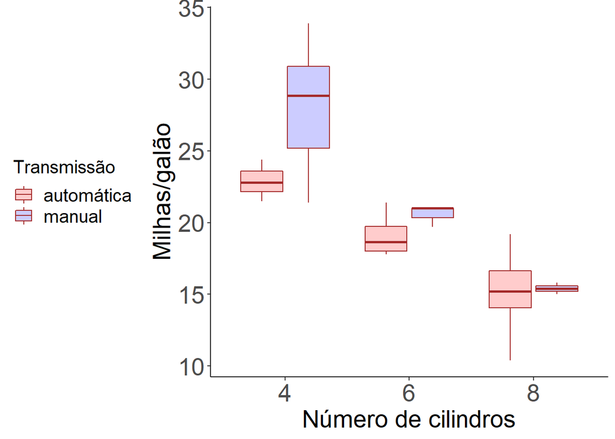

```r
 ggplot(mtcars) +
  geom_boxplot(aes(x = as.factor(cyl), y = mpg, fill=as.factor(am)), colour="brown",
               alpha=0.2) +
  labs(x = "Número de cilindros", y = "Milhas/galão") +
  theme_bw() +
  theme(legend.position="left",
        legend.box = "horizontal",legend.title=element_text(size=15),
        legend.text=element_text(size=15), axis.text=element_text(size=20),
        axis.title=element_text(size=20), axis.line = element_line(colour = "black"),
        panel.grid.major = element_blank(),
        panel.grid.minor = element_blank(),
        panel.border = element_blank(),
        panel.background = element_blank()) +
  scale_fill_manual(values=c("red", "blue"),
                       name="Transmissão",
                       breaks=c("0", "1"),
                       labels=c("automática", "manual"))
```

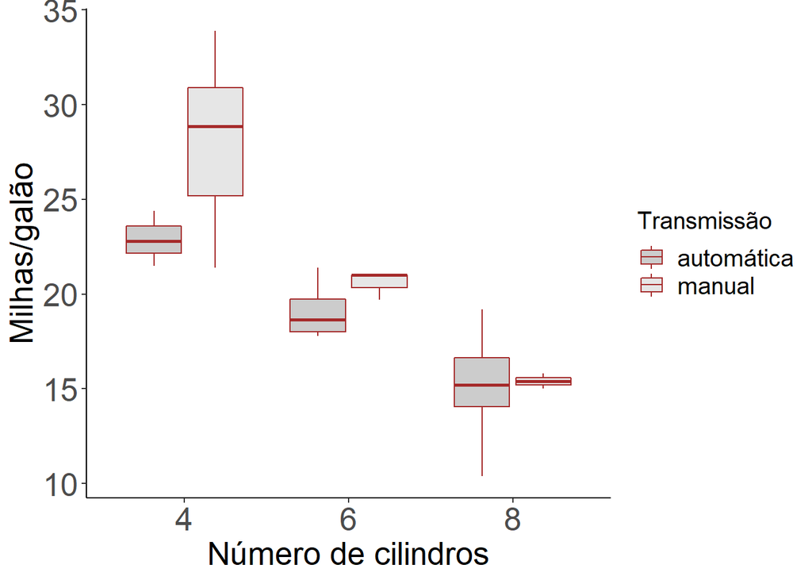

```r
 cor <- gray(0:2 / 2)
 ggplot(mtcars) +
  geom_boxplot(aes(x = as.factor(cyl), y = mpg, fill=as.factor(am)), colour="brown",
               alpha=0.2) +
  labs(x = "Número de cilindros", y = "Milhas/galão") +
  theme_bw() +
  theme(legend.position="right",
        legend.box = "horizontal",legend.title=element_text(size=15),
        legend.text=element_text(size=15), axis.text=element_text(size=20),
        axis.title=element_text(size=20), axis.line = element_line(colour = "black"),
        panel.grid.major = element_blank(),
        panel.grid.minor = element_blank(),
        panel.border = element_blank(),
        panel.background = element_blank()) +
  scale_fill_manual(values=cor,
                       name="Transmissão",
                       breaks=c("0", "1"),
                       labels=c("automática", "manual"))
```

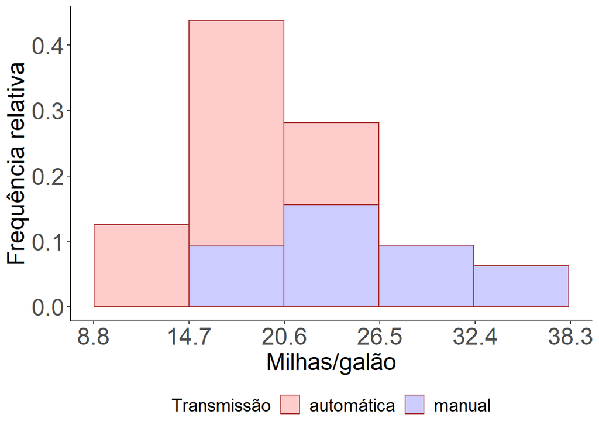

```r
 ggplot(mtcars) +
  geom_histogram(aes(x = mpg, y = (..count..)/sum(..count..), fill=as.factor(am)),
                 bins=5, colour="brown", alpha=0.2)+
  labs(x = "Milhas/galão", y = "Frequência relativa") +
  scale_y_continuous(breaks = c(seq(0,1,0.1)))+
  scale_x_continuous(breaks = c(seq(8.8,38.3,5.9))) +
  theme_bw() +
  theme(legend.position="bottom",
        legend.box = "horizontal",legend.title=element_text(size=15),
        legend.text=element_text(size=15), axis.text=element_text(size=20),
        axis.title=element_text(size=20), axis.line = element_line(colour = "black"),
        panel.grid.major = element_blank(),
        panel.grid.minor = element_blank(),
        panel.border = element_blank(),
        panel.background = element_blank()) +
  scale_fill_manual(values=c("red", "blue"),
                    name="Transmissão",
                    breaks=c("0", "1"),
                    labels=c("automática", "manual"))
```

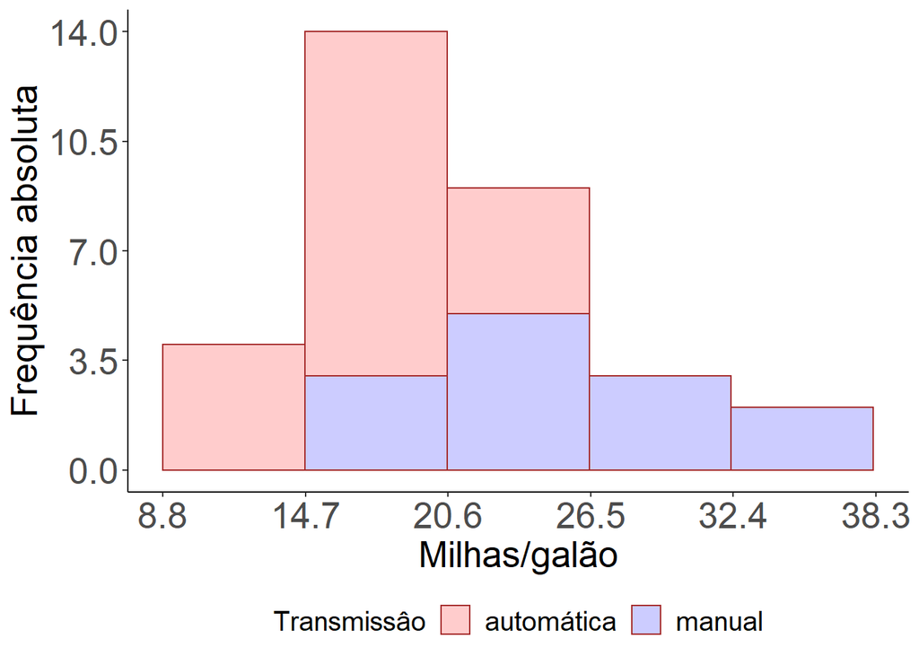

```r
 ggplot(mtcars) +
  geom_histogram(aes(x = mpg, y = (..count..), fill=as.factor(am)), bins=5,
                 colour="brown", alpha=0.2)+
  labs(x = "Milhas/galão", y = "Frequência absoluta") +
  scale_y_continuous(breaks = c(seq(0,15,3.5))) +
  scale_x_continuous(breaks = c(seq(8.8,38.3,5.9))) +
  theme_bw() +
  theme(legend.position="bottom",
        legend.box = "horizontal",legend.title=element_text(size=15),
        legend.text=element_text(size=15), axis.text=element_text(size=20),
        axis.title=element_text(size=20), axis.line = element_line(colour = "black"),
        panel.grid.major = element_blank(),
        panel.grid.minor = element_blank(),
        panel.border = element_blank(),
        panel.background = element_blank()) +
  scale_fill_manual(values=c("red", "blue"),
                    name="Transmissâo",
                    breaks=c("0", "1"),
                    labels=c("automática", "manual"))
```

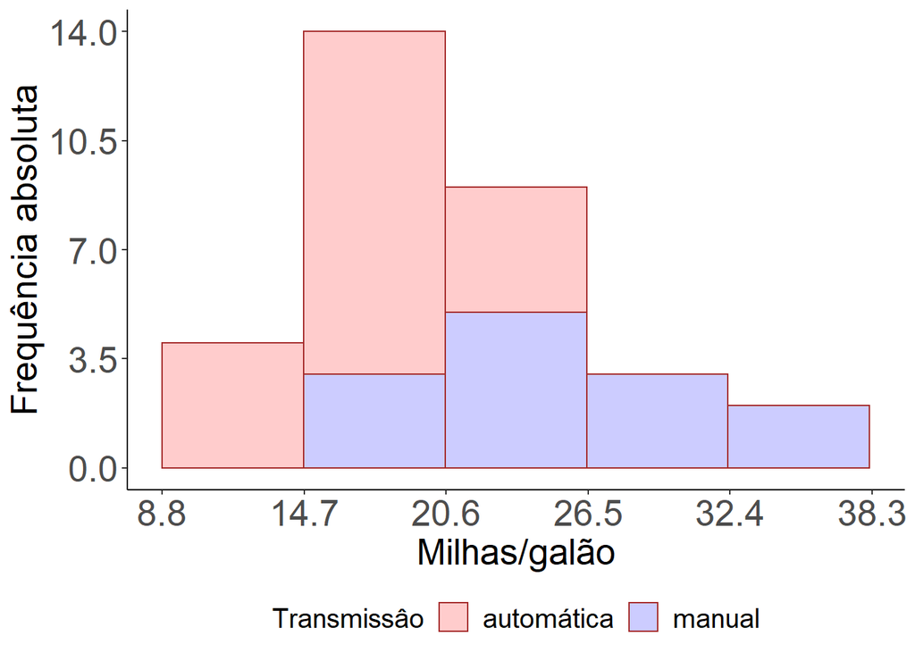

```r
 ggplot(mtcars) +
  geom_histogram(aes(x = mpg, y = (..count..), fill=as.factor(am)), bins=5,
                 colour="brown", alpha=0.2)+
  labs(x = "Milhas/galão", y = "Frequência absoluta") +
  scale_y_continuous(breaks = c(seq(0,15,3.5))) +
  scale_x_continuous(breaks = c(seq(8.8,38.3,5.9))) +
  theme_bw() +
  theme(legend.position="bottom",
        legend.box = "horizontal",legend.title=element_text(size=15),
        legend.text=element_text(size=15), axis.text=element_text(size=20),
        axis.title=element_text(size=20), axis.line = element_line(colour = "black"),
        panel.grid.major = element_blank(),
        panel.grid.minor = element_blank(),
        panel.border = element_blank(),
        panel.background = element_blank()) +
  scale_fill_manual(values=c("red", "blue"),
                    name="Transmissâo",
                    breaks=c("0", "1"),
                    labels=c("automática", "manual"))
```

Antes de construírmos o próximo histograma, precisamos apresentar a função `facet` do ggplot2. Esta função permite a construção de gráficos em `facetas`. O que é isso? Suponha que estamos interessados em construírmos um histograma baseado no anteriormente apresentado. Mas o nosso interesse maior é apresentar um histograma individual para cada tipo de transmissão `am` considerando a variável contínua `mpg`. Abaixo apresentamos a construção deste histograma.

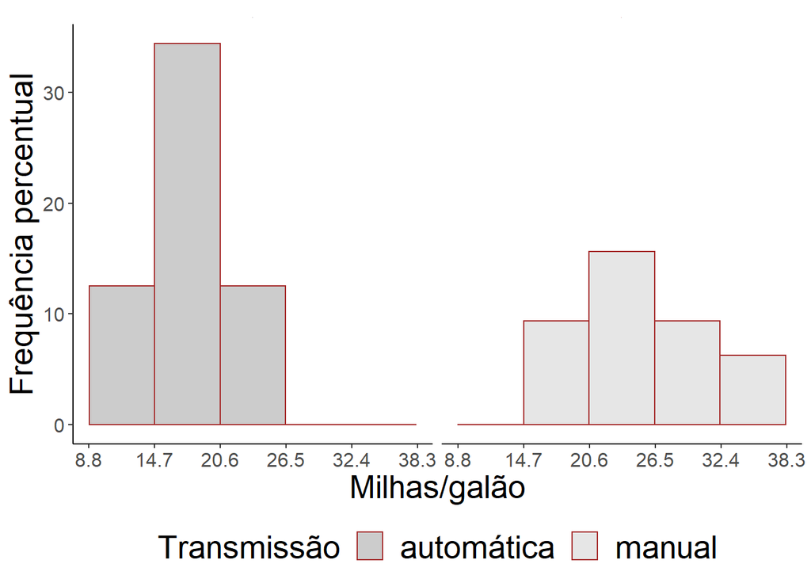

```r
 cor <- gray(0:1 / 2)
 ggplot(mtcars) +
  geom_histogram(aes(x = mpg, y = (..count..)/sum(..count..)*100, fill=as.factor(am)),
                 bins=5, colour="brown", alpha=0.2)+
  facet_wrap(~am)+
  labs(x = "Milhas/galão", y = "Frequência percentual") +
  scale_y_continuous(breaks = c(seq(0,60,10))) +
  scale_x_continuous(breaks = c(seq(8.8,38.3,5.9))) +
  theme_bw() +
  theme(legend.position="bottom",
        legend.box = "horizontal",legend.title=element_text(size=20),
        legend.text=element_text(size=20), axis.text=element_text(size=12),
        axis.title=element_text(size=20), axis.line = element_line(colour = "black"),
        strip.text.x = element_text(size=0),
        strip.background = element_blank(),
        panel.grid.major = element_blank(),
        panel.grid.minor = element_blank(),
        panel.border = element_blank(),
        panel.background = element_blank()) +
  scale_fill_manual(values=cor,
                    name="Transmissão",
                    breaks=c("0", "1"),
                    labels=c("automática", "manual"))
```

Vamos agora apresentar um exemplo de como construir um gráfico de tendência destacando-se os pontos de dispersão dos dados.

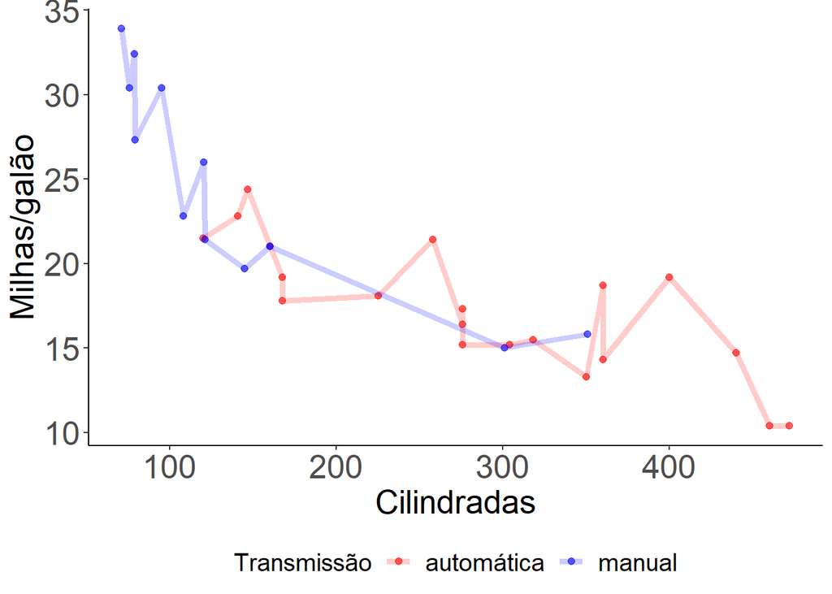

```r
 ggplot(mtcars, aes(x = disp, y = mpg)) +
  geom_point(aes(colour=as.factor(am)), alpha=0.6, size=1.7)+
  geom_line(aes(colour=as.factor(am)), alpha=0.2, size=1.7, linetype=1)+
  labs(x = "Cilindradas", y = "Milhas/galão") +
  theme_bw() +
  theme(legend.position="bottom",
        legend.box = "horizontal",legend.title=element_text(size=15),
        legend.text=element_text(size=15), axis.text=element_text(size=20),
        axis.title=element_text(size=20), axis.line = element_line(colour = "black"),
        panel.grid.major = element_blank(),
        panel.grid.minor = element_blank(),
        panel.border = element_blank(),
        panel.background = element_blank()) +
  scale_colour_manual(values=c("red", "blue"),
                    name="Transmissão",
                    breaks=c("0", "1"),
                    labels=c("automática", "manual"))
```

Como o usuário faria para construir estes histogramas e gráficos de tendência sem utilizar a classificação por níveis da variável `am`? A construção destes gráficos fica como exercício para o usuário.

Vamos agora apresentar um gráfico de barras para a variável `cyl`, separadas por tipo de transmissão `am`.

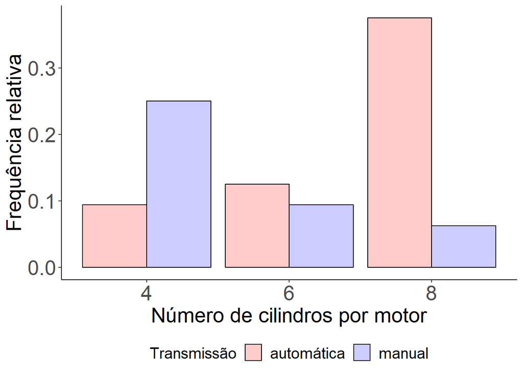

```r
ggplot(mtcars, aes(x = as.factor(cyl))) +
  geom_bar(aes(y = (..count..)/sum(..count..), fill=as.factor(am)),
            position = "dodge", colour="black", alpha=0.2)+
  labs(x = "Número de cilindros por motor", y = "Frequência relativa") +
  theme_bw() +
  theme(legend.position="bottom",
        legend.box = "horizontal",legend.title=element_text(size=15),
        legend.text=element_text(size=15), axis.text=element_text(size=20),
        axis.title=element_text(size=20), axis.line = element_line(colour = "black"),
        panel.grid.major = element_blank(),
        panel.grid.minor = element_blank(),
        panel.border = element_blank(),
        panel.background = element_blank()) +
  scale_fill_manual(values=c("red", "blue"),
                    name="Transmissão",
                    breaks=c("0", "1"),
                    labels=c("automática", "manual"))
```

Utilizando a função `facet`, apresentamos o gráfico de barras para `cyl` separado por cada tipo de transmissão.

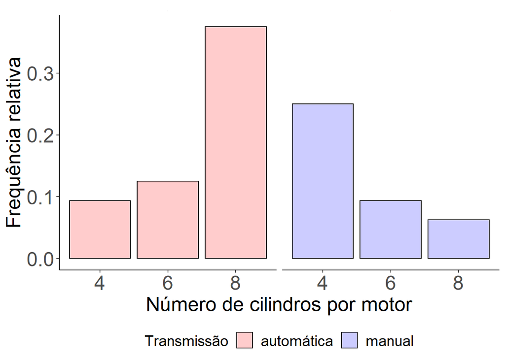

```r
ggplot(mtcars, aes(x = as.factor(cyl))) +
  geom_bar(aes(y = (..count..)/sum(..count..), fill=as.factor(am)),
            position = "dodge", colour="black", alpha=0.2)+
  facet_wrap(~as.factor(am))+
  labs(x = "Número de cilindros por motor", y = "Frequência relativa") +
  theme_bw() +
  theme(legend.position="bottom",
        legend.box = "horizontal",legend.title=element_text(size=15),
        legend.text=element_text(size=15), axis.text=element_text(size=20),
        axis.title=element_text(size=20), axis.line = element_line(colour = "black"),
        strip.text.x = element_text(size=0),
        strip.background = element_blank(),
        panel.grid.major = element_blank(),
        panel.grid.minor = element_blank(),
        panel.border = element_blank(),
        panel.background = element_blank()) +
  scale_fill_manual(values=c("red", "blue"),
                    name="Transmissão",
                    breaks=c("0", "1"),
                    labels=c("automática", "manual"))
```

Nossos gráficos já estão com uma boa qualidade para serem apresentados em alguma revista científica.

## Construindo gráficos a partir de um conjunto de dados original usando os pacotes `tydeverse`, `tibble` e `dplyr` do R.

O que preciso saber do pacote dplyr:

| Funções | Resultados |
| --- | --- |
| filter() | seleciona observações das variáveis por seus valores assumidos |
| arrange() | reordena as linhas (observações) |
| select() | seleciona variáveis por seus nomes (rótulos) |
| mutate() | cria novas variáveis com funções de variáveis existentes |
| summarize() | reune muitos valores em um único resumo |
| group_by() | muda o escopo de cada função anterior em todo o conjunto de dados para operar grupo por grupo. |

Uma vez apresentado as funções do pacote `dplyr`, vamos agora apresentar os argumento dessas funções. O primeiro argumento é um `data frame`. Os argumentos subsequentes descrevem o que fazer com o data frame usando os nomes das variáveis sem aspas. Para exemplicar, vamos considerar o conjunto de dados `flights` disponível no pacote `nycflights13`. Esse conjunto de dados trata de todos os voos diários da cidade de New York no ano de 2013.

```r
library(tidyverse)
library(tibble)
library(dplyr)
library(nycflights13)
data <- flights
data
```

```
## # A tibble: 336,776 x 19
##     year month   day dep_time sched_dep_time dep_delay arr_time
##    <int> <int> <int>    <int>          <int>     <dbl>    <int>
##  1  2013     1     1      517            515         2      830
##  2  2013     1     1      533            529         4      850
##  3  2013     1     1      542            540         2      923
##  4  2013     1     1      544            545        -1     1004
##  5  2013     1     1      554            600        -6      812
##  6  2013     1     1      554            558        -4      740
##  7  2013     1     1      555            600        -5      913
##  8  2013     1     1      557            600        -3      709
##  9  2013     1     1      557            600        -3      838
## 10  2013     1     1      558            600        -2      753
## # ... with 336,766 more rows, and 12 more variables: sched_arr_time <int>,
## #   arr_delay <dbl>, carrier <chr>, flight <int>, tailnum <chr>,
## #   origin <chr>, dest <chr>, air_time <dbl>, distance <dbl>, hour <dbl>,
## #   minute <dbl>, time_hour <dttm>
```

Não se preocupe com a estrutura apresentada nesse conjunto de dados. Trata-se de um `tibble`, um `data frame` com algumas particularidades. Note que essas estrutura de `data frame` traz algumas informações, como a dimensão dos dados, o tipo de variável que está em cada uma das colunas (categórica, inteiro, caractere, etc.), entre outras.

| Representação | Tipo de variável |
| --- | --- |
| int | números inteiros |
| dbl | doubles (números reais) |
| chr | vetores de caracteres (strings) |
| dttm | datas-tempos (uma data + um horário) |
| fctr | valores lógicos (TRUE ou FALSE) |
| date | datas |

Antes de apresentarmos as funções precisamos conhecer alguns caracteres lógicos e suas representações.

| Caractere lógico | Representação |
| --- | --- |
| == | igual |
| & | conectivo `e` (interseção) |
| \| | conectivo `ou` (união) |
| > | maior do que |
| < | menor do que |
| >= | maior do que ou igual a |
| <= | menor do que ou igual a |
| != | diferente |
| %in% | concatenar |

As funções do pacote `dplyr`.

```r
filter(data, month == 1, dep_delay >= 1)
```

```
## # A tibble: 9,662 x 19
##     year month   day dep_time sched_dep_time dep_delay arr_time
##    <int> <int> <int>    <int>          <int>     <dbl>    <int>
##  1  2013     1     1      517            515         2      830
##  2  2013     1     1      533            529         4      850
##  3  2013     1     1      542            540         2      923
##  4  2013     1     1      601            600         1      844
##  5  2013     1     1      608            600         8      807
##  6  2013     1     1      611            600        11      945
##  7  2013     1     1      613            610         3      925
##  8  2013     1     1      623            610        13      920
##  9  2013     1     1      632            608        24      740
## 10  2013     1     1      644            636         8      931
## # ... with 9,652 more rows, and 12 more variables: sched_arr_time <int>,
## #   arr_delay <dbl>, carrier <chr>, flight <int>, tailnum <chr>,
## #   origin <chr>, dest <chr>, air_time <dbl>, distance <dbl>, hour <dbl>,
## #   minute <dbl>, time_hour <dttm>
```

```r
arrange(data, month)
```

```
## # A tibble: 336,776 x 19
##     year month   day dep_time sched_dep_time dep_delay arr_time
##    <int> <int> <int>    <int>          <int>     <dbl>    <int>
##  1  2013     1     1      517            515         2      830
##  2  2013     1     1      533            529         4      850
##  3  2013     1     1      542            540         2      923
##  4  2013     1     1      544            545        -1     1004
##  5  2013     1     1      554            600        -6      812
##  6  2013     1     1      554            558        -4      740
##  7  2013     1     1      555            600        -5      913
##  8  2013     1     1      557            600        -3      709
##  9  2013     1     1      557            600        -3      838
## 10  2013     1     1      558            600        -2      753
## # ... with 336,766 more rows, and 12 more variables: sched_arr_time <int>,
## #   arr_delay <dbl>, carrier <chr>, flight <int>, tailnum <chr>,
## #   origin <chr>, dest <chr>, air_time <dbl>, distance <dbl>, hour <dbl>,
## #   minute <dbl>, time_hour <dttm>
```

```r
select(data, year , day,  month, dep_delay)
```

```
## # A tibble: 336,776 x 4
##     year   day month dep_delay
##    <int> <int> <int>     <dbl>
##  1  2013     1     1         2
##  2  2013     1     1         4
##  3  2013     1     1         2
##  4  2013     1     1        -1
##  5  2013     1     1        -6
##  6  2013     1     1        -4
##  7  2013     1     1        -5
##  8  2013     1     1        -3
##  9  2013     1     1        -3
## 10  2013     1     1        -2
## # ... with 336,766 more rows
```

```r
mutate(data, hora= hour/100)
```

```
## # A tibble: 336,776 x 20
##     year month   day dep_time sched_dep_time dep_delay arr_time
##    <int> <int> <int>    <int>          <int>     <dbl>    <int>
##  1  2013     1     1      517            515         2      830
##  2  2013     1     1      533            529         4      850
##  3  2013     1     1      542            540         2      923
##  4  2013     1     1      544            545        -1     1004
##  5  2013     1     1      554            600        -6      812
##  6  2013     1     1      554            558        -4      740
##  7  2013     1     1      555            600        -5      913
##  8  2013     1     1      557            600        -3      709
##  9  2013     1     1      557            600        -3      838
## 10  2013     1     1      558            600        -2      753
## # ... with 336,766 more rows, and 13 more variables: sched_arr_time <int>,
## #   arr_delay <dbl>, carrier <chr>, flight <int>, tailnum <chr>,
## #   origin <chr>, dest <chr>, air_time <dbl>, distance <dbl>, hour <dbl>,
## #   minute <dbl>, time_hour <dttm>, hora <dbl>
```

```r
summarize(data, mean_flight=mean(flight), desv_pad= sd(flight),
                  standard_error=desv_pad/sqrt(n()))
```

```
## # A tibble: 1 x 3
##   mean_flight desv_pad standard_error
##         <dbl>    <dbl>          <dbl>
## 1       1972.    1632.           2.81
```

```r
group_by(data, year, month)
```

```
## # A tibble: 336,776 x 19
## # Groups:   year, month [12]
##     year month   day dep_time sched_dep_time dep_delay arr_time
##    <int> <int> <int>    <int>          <int>     <dbl>    <int>
##  1  2013     1     1      517            515         2      830
##  2  2013     1     1      533            529         4      850
##  3  2013     1     1      542            540         2      923
##  4  2013     1     1      544            545        -1     1004
##  5  2013     1     1      554            600        -6      812
##  6  2013     1     1      554            558        -4      740
##  7  2013     1     1      555            600        -5      913
##  8  2013     1     1      557            600        -3      709
##  9  2013     1     1      557            600        -3      838
## 10  2013     1     1      558            600        -2      753
## # ... with 336,766 more rows, and 12 more variables: sched_arr_time <int>,
## #   arr_delay <dbl>, carrier <chr>, flight <int>, tailnum <chr>,
## #   origin <chr>, dest <chr>, air_time <dbl>, distance <dbl>, hour <dbl>,
## #   minute <dbl>, time_hour <dttm>
```

Esse pacote `dplyr`é muito útil quando desejamos realizar uma análise exploratória de nossos dados. Vamos então construir alguns gráficos utilizando os recursos desse pacote e também do `ggplot2`.

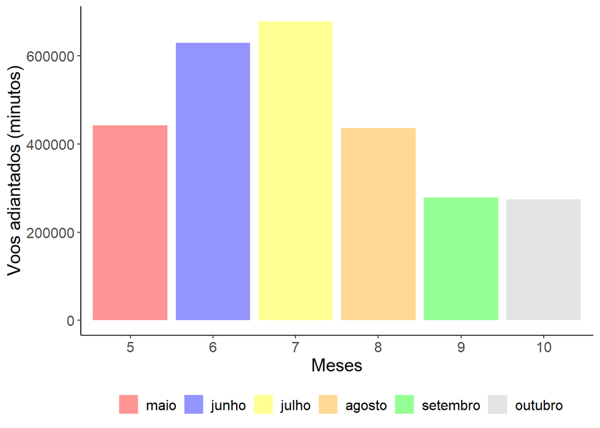

```r
options(scipen=10000)
Dados <- select(data, year , day,  month, dep_delay)
resultados <- filter(Dados, dep_delay >=2 & month %in% c(5, 6, 7, 8,9, 10))
ggplot(resultados)+
  geom_col(aes(x=as.factor(month), y=dep_delay, fill=as.factor(month)), alpha=0.42)+
  labs(x = "Meses", y = "Voos adiantados (minutos)") +
  theme_bw() +
  theme(legend.position="bottom",
        legend.box = "horizontal",legend.title=element_text(size=12),
        legend.text=element_text(size=12), axis.text=element_text(size=12),
        axis.title=element_text(size=15), axis.line = element_line(colour = "black"),
        strip.text.x = element_text(size=0),
        strip.background = element_blank(),
        panel.grid.major = element_blank(),
        panel.grid.minor = element_blank(),
        panel.border = element_blank(),
        panel.background = element_blank()) +
        guides(fill = guide_legend(nrow = 1))+
  scale_fill_manual(values=c("red", "blue", "yellow", "orange", "green", "gray", "cyan"), name="",
breaks=c("5", "6", "7", "8", "9", "10"),
labels=c("maio", "junho", "julho", "agosto", "setembro", "outubro"))
```

Um fato curioso deve ser notado: quando manipulamos o conto de dados `data` com as funções `select` e `filter`, nós atribuímos a cada `tibble` gerado por essas funções um rótulo. Agora, imagine que, dentro do mesmo conjunto de dados, nós precisamos utilizar todas as seis funções do pacote `dplyr`. Seria inviável proceder como da forma anterior.

Para corrigir esse problema, foi criado o pacote `magrittr` onde foi criado o operador pipe `%>%`. Essa ferramenta é utilizada para expressar claramente uma sequência de múltiplas operações. Este pacote já é carregado automaticamente como `dplyr`. Vejamos como funciona no exemplo anterior.

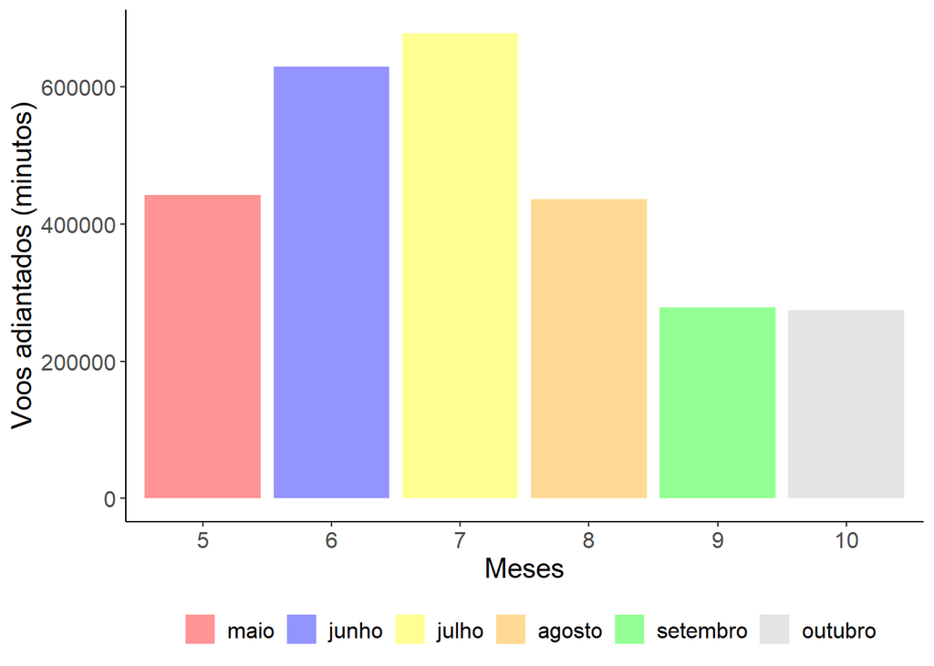

```r
options(scipen=10000)
Resultados <-  data %>%
  select(year , day,  month, dep_delay)%>%
  filter(dep_delay >=2 & month %in% c(5, 6, 7, 8,9, 10))
ggplot(Resultados)+
  geom_col(aes(x=as.factor(month), y=dep_delay, fill=as.factor(month)), alpha=0.42)+
  labs(x = "Meses", y = "Voos adiantados (minutos)") +
  theme_bw() +
  theme(legend.position="bottom",
        legend.box = "horizontal",legend.title=element_text(size=12),
        legend.text=element_text(size=12), axis.text=element_text(size=12),
        axis.title=element_text(size=15), axis.line = element_line(colour = "black"),
        strip.text.x = element_text(size=0),
        strip.background = element_blank(),
        panel.grid.major = element_blank(),
        panel.grid.minor = element_blank(),
        panel.border = element_blank(),
        panel.background = element_blank()) +
        guides(fill = guide_legend(nrow = 1))+
  scale_fill_manual(values=c("red", "blue", "yellow", "orange", "green", "gray", "cyan"), name="",
breaks=c("5", "6", "7", "8", "9", "10"),
labels=c("maio", "junho", "julho", "agosto", "setembro", "outubro"))
```

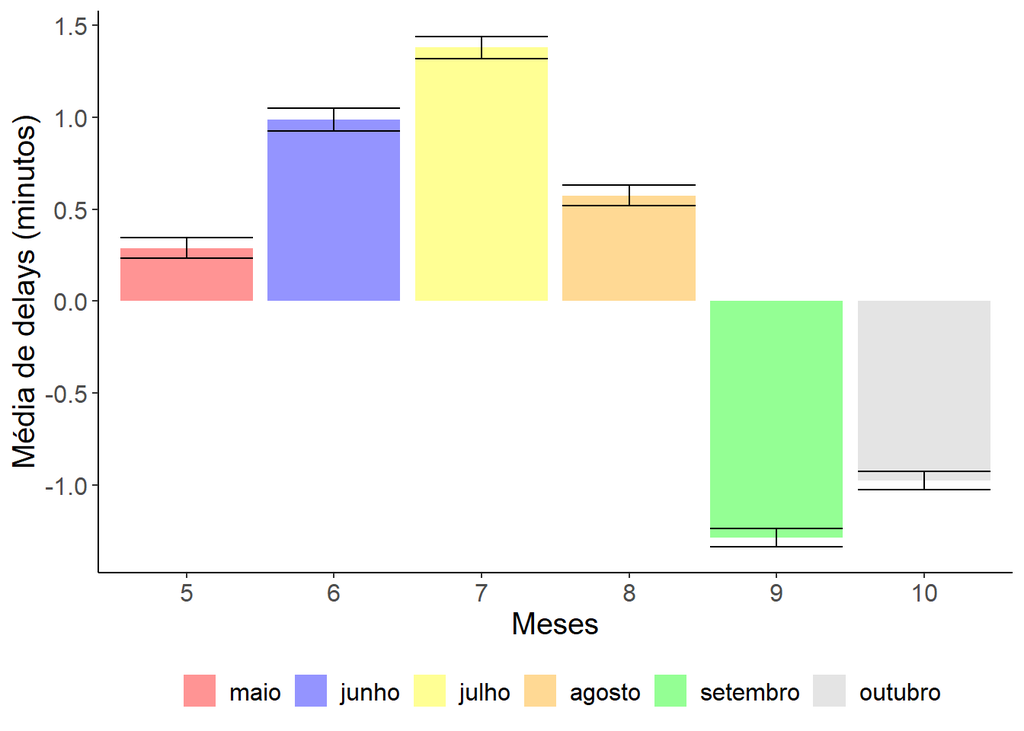

```r
options(scipen=10000)
Delay <-  data %>%
  select(year , day,  month, dep_delay)%>%
  filter(dep_delay >=-10 & dep_delay <= 30 & month %in% c(5, 6, 7, 8,9, 10))%>%
  group_by(month)%>%
  summarize(media=mean(dep_delay, na.rm=TRUE),desv_pad= sd(dep_delay, na.rm=TRUE),
            standard_error=desv_pad/sqrt(n()))
ggplot(Delay, aes(x=as.factor(month), y=media, fill=as.factor(month)))+
  geom_col(alpha=0.42)+
  geom_errorbar(aes(ymin=media-standard_error, ymax=media+standard_error), colour="black")+
  labs(x = "Meses", y = "Média de delays (minutos)") +
  theme_bw() +
  theme(legend.position="bottom",
        legend.box = "horizontal",legend.title=element_text(size=12),
        legend.text=element_text(size=12), axis.text=element_text(size=12),
        axis.title=element_text(size=15), axis.line = element_line(colour = "black"),
        strip.text.x = element_text(size=0),
        strip.background = element_blank(),
        panel.grid.major = element_blank(),
        panel.grid.minor = element_blank(),
        panel.border = element_blank(),
        panel.background = element_blank()) +
        guides(fill = guide_legend(nrow = 1))+
  scale_fill_manual(values=c("red", "blue", "yellow", "orange", "green", "gray", "cyan"), name="",
breaks=c("5", "6", "7", "8", "9", "10"),
labels=c("maio", "junho", "julho", "agosto", "setembro", "outubro"))
```

A partir de agora já podemos construir gráficos descritivos no `ggplt2` com o auxílio do pacote `dplyr`. Deixamos agora algumas atividades para o leitor.

## Atividades

- 1 - Considere as variáveis classe de veículos `class` e quantidade de cilindros `cyl`. Considere também a variável deslocamento (em milhas) na cidade por galão `displ`. Reproduza um gráfico de barras que mostre o número médio de deslocamento na cidade por galão de automóveis das classes `compact` e `subcompact` por quantidade de cilindros. Adicione também as barras de erro para esses dados.
- 2 - Considere as variáveis tipos de transmissão `trans` e fabricante `manufacturer`. Cconstrua um boxplot para a variável `displ` considerando os fabricantes `audi`e `nissan` e os tipos de transmissão `auto(av)` e `manual(m6)`.